# Exploring the NOAA storm database - Tornado’s the real killer

Jacob Grydholt

Wednesday, January 21, 2015

# Synopsis

In this report I aim to describe which type of weather events has the largest impacts in USA. I summarize data from the NOAA storm database and illustrate that tornadoes have the largest impact on human life. Both in terms of health, i.e. number of fatalities and injuries caused and in economic losses.

# Data Processing

```r
library('dplyr')
library('reshape2')
```

```r
library('ggplot2')
```

We load the data through read.csv and use a connection created by ‘bzfile’:

```r
stormdata <- read.csv(bzfile("repdata_data_StormData.csv.bz2", "repdata_data_StormData.csv"))
```

## Fatalities and Injuries

We summarize for fatalitites and injuries using a dplyr expression:

```r
fatalitiesPerEventType <- stormdata %>%
        group_by(EVTYPE) %>%
        summarize(FATALITIES = sum(FATALITIES)) %>%
        arrange(desc(FATALITIES))
injuriesPerEventType <- stormdata %>%
        group_by(EVTYPE) %>%
        summarize(INJURIES = sum(INJURIES)) %>%
        arrange(desc(INJURIES))
```

We find the top 10 for fatalitites:

```r
top10Fatalities <- head(fatalitiesPerEventType, n = 10)
top10Fatalities$EVENT <- factor(top10Fatalities$EVTYPE, levels = top10Fatalities$EVTYPE)
top10Fatalities$EVTYPE <- NULL
top10Fatalities
```

```
## Source: local data frame [10 x 2]
##
##    FATALITIES          EVENT
## 1        5633        TORNADO
## 2        1903 EXCESSIVE HEAT
## 3         978    FLASH FLOOD
## 4         937           HEAT
## 5         816      LIGHTNING
## 6         504      TSTM WIND
## 7         470          FLOOD
## 8         368    RIP CURRENT
## 9         248      HIGH WIND
## 10        224      AVALANCHE
```

and for injuries:

```r
top10Injuries <- head(injuriesPerEventType, n = 10)
top10Injuries$EVENT <- factor(top10Injuries$EVTYPE, levels = top10Injuries$EVTYPE)
top10Injuries$EVTYPE <- NULL
top10Injuries
```

```
## Source: local data frame [10 x 2]
##
##    INJURIES             EVENT
## 1     91346           TORNADO
## 2      6957         TSTM WIND
## 3      6789             FLOOD
## 4      6525    EXCESSIVE HEAT
## 5      5230         LIGHTNING
## 6      2100              HEAT
## 7      1975         ICE STORM
## 8      1777       FLASH FLOOD
## 9      1488 THUNDERSTORM WIND
## 10     1361              HAIL
```

## Economic Damages

```r
stormdata$PROPDMGEXP <- toupper(stormdata$PROPDMGEXP)
stormdata$CROPDMGEXP <- toupper(stormdata$CROPDMGEXP)


dmgExp <- function(x) {
        if (x == "K") {
                return(1000);
        } else if (x == "M") {
                return(1000*1000);
        } else if (x == "G") {
                return(1000*1000*1000);
        }
        return(0);
}


damagesByEventType <- stormdata %>%
        mutate(damage = sapply(PROPDMGEXP, dmgExp) * PROPDMG + sapply(CROPDMGEXP, dmgExp) * CROPDMG) %>%
        group_by(EVTYPE) %>%
        summarize(TOTAL_DAMAGES = sum(damage)) %>%
    arrange(desc(TOTAL_DAMAGES))
```

We calculate the top 10 for the damage types:

```r
top10DamagesByEventType <- head(damagesByEventType, n = 10)
top10DamagesByEventType$EVENT <- factor(top10DamagesByEventType$EVTYPE, levels = top10DamagesByEventType$EVTYPE)
top10DamagesByEventType$EVTYPE <- NULL
top10DamagesByEventType
```

```
## Source: local data frame [10 x 2]
##
##    TOTAL_DAMAGES             EVENT
## 1    52052113590           TORNADO
## 2    27819678250             FLOOD
## 3    16958221170              HAIL
## 4    16562128610       FLASH FLOOD
## 5    13518672000           DROUGHT
## 6     8910229010         HURRICANE
## 7     5038935790         TSTM WIND
## 8     4903712800 HURRICANE/TYPHOON
## 9     4608617560         HIGH WIND
## 10    4020586800          WILDFIRE
```

# Results

## Fatalities and Injuries

We are interested in which events that cause the most damage. At first, we’ll look at fatalities and later turn to injuries to determine which events cost the most in human lives and injuries.

### Fatalities

We plot the data for fatalities:

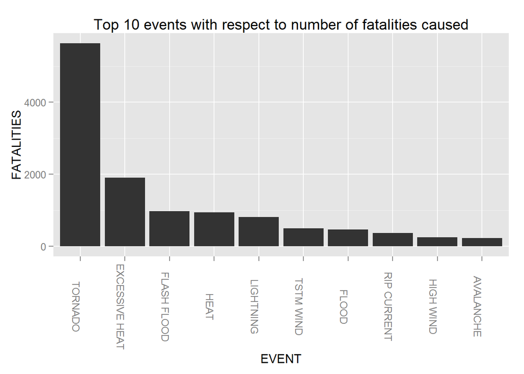

```r
q <- qplot(EVENT, y = FATALITIES, data = top10Fatalities ,geom = "bar", stat = "identity", position = "dodge")
q + ggtitle("Top 10 events with respect to number of fatalities caused") + theme(axis.text.x = element_text(angle=-90))
```

We see that tornadoes and excessive heat are the greatest dangers. The top 10 contains the larger part of the fatalities as they account for

```r
top10FatalitiesSum <- sum(top10Fatalities$FATALITIES)
top10FatalitiesSum
```

```
## [1] 12081
```

whereas the rest combined account for

```r
sum(stormdata$FATALITIES) - top10FatalitiesSum
```

```
## [1] 3064
```

In order to not overlook events with a lot of injuries and few fatalities, we do same analysis for injuries.

### Injuries

Again we start by plotting the data:

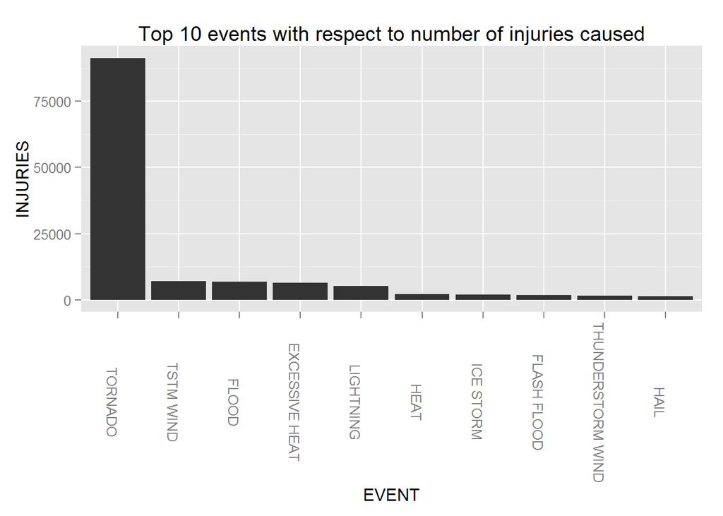

```r
q <- qplot(EVENT, y = INJURIES, data = top10Injuries ,geom = "bar", stat = "identity", position = "dodge")
q + ggtitle("Top 10 events with respect to number of injuries caused") + theme(axis.text.x = element_text(angle=-90))
```

We see that tornadoes and excessive heat are still among the greatest dangers along with thunderstrom wind and flooding. The top 10 contains the larger part of the injuries as they account for

```r
top10InjuriesSum <- sum(top10Injuries$INJURIES)
top10InjuriesSum
```

```
## [1] 125548
```

whereas the rest combined account for

```r
sum(stormdata$INJURIES) - top10InjuriesSum
```

```
## [1] 14980
```

## Damages

We plot the data for the calculated damages per event type:

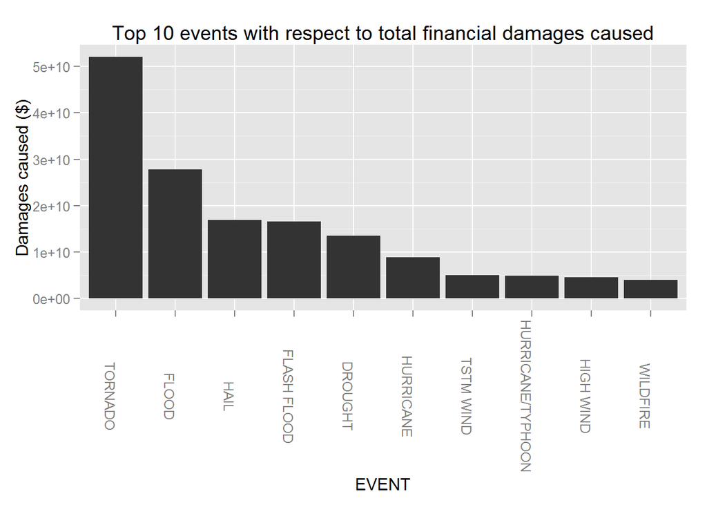

```r
q <- qplot(EVENT, y = TOTAL_DAMAGES, data = top10DamagesByEventType ,geom = "bar", stat = "identity", position = "dodge")
q + ylab("Damages caused ($)") + ggtitle("Top 10 events with respect to total financial damages caused") + theme(axis.text.x = element_text(angle=-90))
```

We see that tornadoes again top the list. Flooding and hail are also repeat visitors to the top of the various lists. Again the top 10 list has the lion’s share.

```r
top10DamagesSum <- sum(top10DamagesByEventType$TOTAL_DAMAGES)
top10DamagesSum
```

```
## [1] 154392895580
```

whereas the rest combined account for (in percentage)

```r
totalDamages <- sum(damagesByEventType$TOTAL_DAMAGES)
((totalDamages - top10DamagesSum)/totalDamages)*100
```

```
## [1] 17.42054
```